# Exploring methods to create a multivariate t-distributed random matrix

Paul W. Egeler, MS, GStat

2017-12-29

*This document is part of the the [`mvrt` package](https://github.com/pegeler/mvrt/). See the README.md for more information on download and installation.*

## Objective

The objective of this R package vignette is to investigate the various ways of creating multivariate normal/t distributions. An algorithm using Cholesky decomposition is used; first in R code, then in C++ code. This is compared to existing methods for creating multivariate random matrices, such as `MASS::mvrnorm` and `mvtnorm::rmvt`.

The matrices are compared using summary statistics and graphics (histograms). The distributions are assessed for “believability”. Methods are also explored for ensuring that the specified correlation/covariance structure is preserved, despite the random process of number generation. Finally, benchmarking is perfromed to determine performance differences.

## Setup

### Defining the data

We will specify the sample n pairs, means, correlation matrix, and variances. The correlation matrix and variances will be used to generate a covariance matrix, which will be used by the random number generator.

```r
n <- 30
mu <- c(5,4)
R <- matrix(c(1,.9,.9,1),2,2)
var <- c(2.5,2)

S <- mvrt::convert_R2S(R, var)
```

### Defining the multivariate t-distributed random matrix generator functions

First we will define the random number generator functions in R. We will compare the performance of R code with- and without `for` loops. Well-optimized R code may be sufficiently performant as to not warrant the implementation of a compiled alternative.

```r
# With a for loop
mvrt_R_a <- function(n, mu, S, df = n - 1) {

  g.t <- t(chol(S))

  bivMat <- matrix(0,nrow = length(mu), ncol = n)

  for (i in seq_len(n)) {
    bivMat[,i] <- mu + g.t %*% rt(length(mu), df)
  }

  t(bivMat)

}

# Without a for loop
mvrt_R_b <- function(n, mu, S, df = n - 1) {

  g <- chol(S)

  random_matrix <- matrix(rt(n*length(mu), df),nrow = length(mu))
  deviation <- t(g) %*% random_matrix

  t(mu + deviation)

}
```

### Compiling and loading the C++ mvrt random matrix generator

Next we will load in a function written in C++. The expectation is that the C++ code will be faster than the R code, possibly by several orders of magnitude.

```r
Rcpp::sourceCpp("../src/mvrt.cpp")
```

The code that was loaded is below.

```c
#include <RcppArmadillo.h>
// [[Rcpp::depends(RcppArmadillo)]]

using namespace Rcpp;

//' @rdname mvrt
//' @export
// [[Rcpp::export]]
arma::mat mvrt(int n, arma::vec mu, arma::mat S, int df=1)
{

  // Cholesky decomp and transpose covariance matrix
  arma::mat g = chol(S).t();

  // Generate the random data
  arma::vec x_vec = as< arma::vec >( rt(mu.size() * n, df) );
  arma::mat x = arma::mat( (const double*)x_vec.begin(), mu.size(), n );

  // Give the random data covariance structure and add mean offset
  x = g * x;
  x.each_col() += mu;

  return x.t();
}
```

### Define our function for getting a distribution of correlation coefficients

This function will take a function and its arguments and run it a specified number of times, performing a correlation on the output and extracting the off-diagonal element. Essentially, we can use this to run each random number generator an arbitrary number of times and get the Pearson’s correlation for each pair of vectors created. This can be used to examine the distribution of correlation coefficients that can be expected from the random generation processes. Note the random seed parameter which can be set for reproducibility.

```r
get_cor_dist <- function(FUN, times, ..., seed = 999) {

  set.seed(seed)

  FUN <- match.fun(FUN)

  my_call <- as.call(list(FUN, ...))

  out <- numeric(times)

  for (i in seq_len(times)) {

    out[i] <- cor(eval(my_call))[2]

  }

  out

}
```

### Generating the distributions of correlation coeffiencts using sever random matrix generators

Using the function above, we will create similar multivariate t-distributed (or normally-distributed) random matrices using several functions.

```r
mvrtRa_dist <-  get_cor_dist(mvrt_R_a, 100, n, mu, S)
mvrtRb_dist <-  get_cor_dist(mvrt_R_b, 100, n, mu, S)
mvrt_dist <-    get_cor_dist(mvrt, 100, n, mu, S, n - 1)
MASS_dist <-    get_cor_dist(MASS::mvrnorm, 100, n, mu, S)
mvtnorm_dist <- get_cor_dist(mvtnorm::rmvt, 100, n, S, n - 1)
```

## Analysis

### Checking the algorithm

#### Homogenous outputs

First let’s check that our three home-grown functions produce identical results.

```r
if (identical(mvrtRa_dist, mvrt_dist) && identical(mvrtRb_dist, mvrt_dist)) {
  message("Distributions of correlation coefficients are identical")
} else {
  message("Distributions of correlation coefficients are NOT identical")
}
```

```
## Distributions of correlation coefficients are identical
```

```r
if (
  identical(
    (mvrt_sample <- {set.seed(999); mvrt(n, mu, S, n - 1)}),
    {set.seed(999); mvrt_R_a(n, mu, S)}
    ) &&
  identical(
    mvrt_sample,
    {set.seed(999); mvrt_R_b(n, mu, S)}
    )
) {
  message("Random samples generated match")
} else {
  message("Random samples generated do NOT match")
}
```

```
## Random samples generated match
```

It appears that we are successful in that the three functions produce identical output. Therefore, we must only examine one function’s output when doing distribution analysis, rather than all three.

#### Inspecting outputted means and variances

Let’s run a couple of checks to make sure that the algorithm is at least giving us data with approximately correct means and variances.

```r
# Mean mu
colMeans(t(sapply(lapply(rep(30,100), mvrt, mu, S, n - 1),colMeans)))
```

```
## [1] 4.943320 3.951612
```

```r
# Mean var
colMeans(t(sapply(lapply(rep(30,100), mvrt, mu, S, n - 1), apply, 2, var)))
```

```
## [1] 2.607499 2.103790
```

Means are close and variances are just a little higher than those specified in the covariance matrix, which we might expect from a relatively small sample size.

#### An individual sample

Let’s pull a single sample of n = 30. We can check the mean, variance, and correlation.

```r
mvrt_sample <- mvrt(n, mu, S, n - 1)

colMeans(mvrt_sample)
```

```
## [1] 5.261327 4.106697
```

```r
apply(mvrt_sample, 2,var)
```

```
## [1] 2.157964 1.204207
```

```r
cor(mvrt_sample)
```

```
##           [,1]      [,2]
## [1,] 1.0000000 0.8381404
## [2,] 0.8381404 1.0000000
```

How does a plot of the data look?

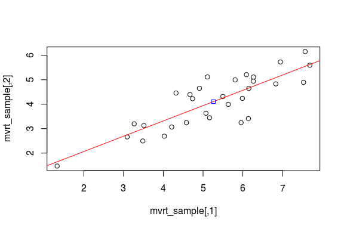

```r
plot(mvrt_sample)
# Regression line
abline(lm(mvrt_sample[,2] ~ mvrt_sample[,1]), col = "red")

# Center of points
points(mean(mvrt_sample[,1]), mean(mvrt_sample[,2]), col = "blue", pch = 22)
```

OK. So we are fairly confident that we are getting the data we requested. Now let’s look at how the correlation coefficients are distributed over several simulations.

### Comparing the correlation coefficient distributions of the various functions

```r
# Summary of the distributions
summary(mvrt_dist)
```

```
##    Min. 1st Qu.  Median    Mean 3rd Qu.    Max.
##  0.7809  0.8804  0.9084  0.9043  0.9316  0.9588
```

```r
summary(MASS_dist)
```

```
##    Min. 1st Qu.  Median    Mean 3rd Qu.    Max.
##  0.7500  0.8831  0.9082  0.9010  0.9219  0.9661
```

```r
summary(mvtnorm_dist)
```

```
##    Min. 1st Qu.  Median    Mean 3rd Qu.    Max.
##  0.7777  0.8816  0.9030  0.8980  0.9251  0.9570
```

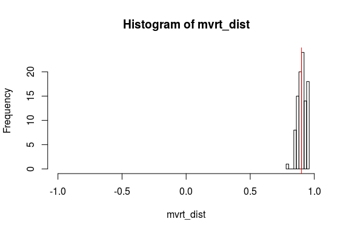

```r
# Graphical representations
my_hist <- function (data) {
  hist(
    data,
    xlim = c(-1,1),
    breaks = "fd",
    main = paste("Histogram of",deparse(substitute(data))),
    xlab = deparse(substitute(data))
  )

  abline(v = 0.9, col = 'red')
}

my_hist(mvrt_dist)
```

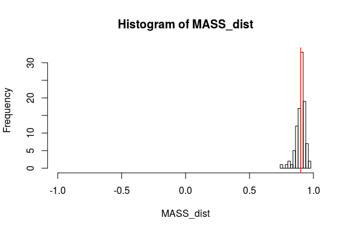

```r
my_hist(MASS_dist)
```

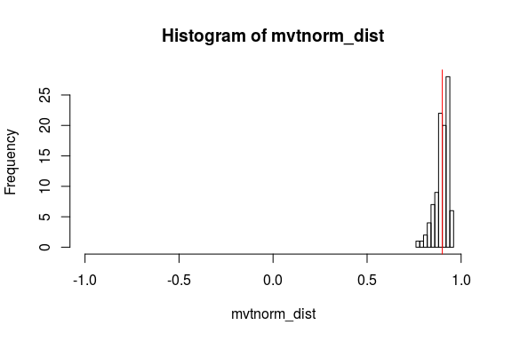

```r
my_hist(mvtnorm_dist)
```

## Guaranteeing outputs are within a specified range

What if we would like to specify that the matrix of values returned is within a reasonable margin to the specified correlation coefficient? This can be done through iterative generation of the random sample with acceptance checks at each step. A matrix norm of the difference in correlation matrices (between generated and specified) may be used as an intuitive check. We may specify that the maximum modulus of the difference between specified and returned correlation matrix elements is below a given threshold.

The determinant may also be used (and is potentially faster). However the norm may be more easily interpreted since the element-wise maximum modulus is a good way for the user to specify an acceptance criterion.

### Choosing the matrix norm over the determinant

Why use the matrix norm rather than the determinant or some other measure? Because it is the most intuitive. The matrix norm is computed several ways. We will use the maximum modulus (absolute value) method, which is equivalent to performing `max(abs())` on a matrix. This means that in we can specify the maximum devation of any element within the resultant correlation matrix generated by random sample versus the specified. For example, specifying a maximum matrix norm of 0.05 means that the Pearson’s correlation generated from outputted values will be within $\pm$ 0.05 of the Pearson’s correlation used as the input correlation matrix (as derived form the input covariance matrix).

To demonstrate, we will create a reference correlation matrix and then compare it to a set of contender matrices using the determinant and norm.

```r
# A single reference matrix
R_ref <- mvrt::make_cor_mat(.9)
R_ref
```

```
##      [,1] [,2]
## [1,]  1.0  0.9
## [2,]  0.9  1.0
```

```r
# A set of test matrices
R_test <- lapply(seq(.5,1,.05), mvrt::make_cor_mat)
R_test[[1]]
```

```
##      [,1] [,2]
## [1,]  1.0  0.5
## [2,]  0.5  1.0
```

```r
# What does the determinant look like for the difference matrices?
sapply(R_test, function(a,b) det(a - b), R_ref)
```

```
##  [1] -0.1600 -0.1225 -0.0900 -0.0625 -0.0400 -0.0225 -0.0100 -0.0025
##  [9]  0.0000 -0.0025 -0.0100
```

```r
# And the matrix norm?
sapply(R_test, function(a,b) norm(a - b, "m"), R_ref)
```

```
##  [1] 0.40 0.35 0.30 0.25 0.20 0.15 0.10 0.05 0.00 0.05 0.10
```

The user is more likely to understand how to specify a max norm than a max determinant.

### Iterative function definitions

Below we see two function definitions which perform the same task but implement different programming techniques. The first utilizes recursive function calls, while the second uses a `for` loop to repeat sample generation until the acceptance criterion is met.

```r
# Using recursive function calls
mvrt_R_c <- function(n, mu, S, df = n - 1, max.norm = 0.05, type.norm = "m") {

  g <- chol(S)

  random_matrix <- matrix(rt(n*length(mu), df),nrow = length(mu))
  deviation <- t(g) %*% random_matrix

  out <- t(mu + deviation)

  if (norm(cov2cor(S) - cor(out), type = type.norm) <= max.norm) {
    return(out)
  } else {
    eval(match.call())
  }

}


# Using the for loop
mvrt_R_d <- function(
  n,
  mu,
  S,
  df = n - 1,
  max_norm = 0.05,
  max_iterations = 1000,
  type_norm = "m")
{

  g.t <- t(chol(S))

  R_ref <- cov2cor(S)

  for (iterations in seq_len(max_iterations)) {

    random_matrix <- matrix(rt(n*length(mu), df),nrow = length(mu))
    deviation <- g.t %*% random_matrix

    if (norm(R_ref - cor(t(mu + deviation)), type = type_norm) <= max_norm)
      return(t(mu + deviation))

  }

  stop(
    "Correlation structure with max norm of ", max_norm,
    " was not obtained in ", max_iterations, " iterations"
    )

}
```

We may also include a `C++` function to achieve this.

```r
Rcpp::sourceCpp("../src/mvrt2.cpp")
```

The code that was loaded is below.

```c
#include <RcppArmadillo.h>
// [[Rcpp::depends(RcppArmadillo)]]

using namespace Rcpp;

//' @rdname mvrt
//' @export
// [[Rcpp::export]]
arma::mat mvrt2(
    int n,
    arma::vec mu,
    arma::mat S,
    int df=1,
    double max_norm=2,
    int max_iterations=1000
  )
{

  // Cholesky decomp and transpose covariance matrix
  arma::mat g = chol(S).t();

  // Get correlation matrix of user-input S matrix
  arma::mat V_sqrt_inv = diagmat(1 / sqrt(S.diag()));
  arma::mat target_cor = V_sqrt_inv * S * V_sqrt_inv;

  for (int iteration=0; iteration < max_iterations; iteration++)
  {

    // Generate the random data
    arma::vec x_vec = as< arma::vec >( rt(mu.size() * n, df) );
    arma::mat x = arma::mat( (const double*)x_vec.begin(), mu.size(), n );

    // Give the random data covariance structure and add mean offset
    x = g * x;
    x.each_col() += mu;

    // Compare to target and retrun if meets specification
    arma::mat diff_matrix = abs(cor(x.t()) - target_cor);

    if (diff_matrix.max() <= max_norm) return x.t();

  }

  stop(
    "Did not generate matrix with max norm of %f in %i iterations",
    max_norm,
    max_iterations
  );

}
```

### Checking our work

Now lets see if the distributions tighten up with our new functions. We should now see that the correlation coefficient of each of our randomly generated samples will not stray more than 0.05 from the correlation of the correlation matrix used to specify the covariance structure of the data.

```r
mvrtRc_dist <-  get_cor_dist(mvrt_R_c, 100, n, mu, S)
mvrtRd_dist <-  get_cor_dist(mvrt_R_d, 100, n, mu, S)
mvrt2_dist <-   get_cor_dist(mvrt2,    100, n, mu, S, n - 1, 0.05)

if (identical(mvrtRc_dist, mvrtRd_dist) && identical(mvrtRc_dist, mvrt2_dist)) {
  message("Distributions of correlation coefficients are identical")
} else {
  message("Distributions of correlation coefficients are NOT identical")
}
```

```
## Distributions of correlation coefficients are identical
```

```r
summary(mvrtRc_dist)
```

```
##    Min. 1st Qu.  Median    Mean 3rd Qu.    Max.
##  0.8545  0.8801  0.9070  0.9028  0.9257  0.9472
```

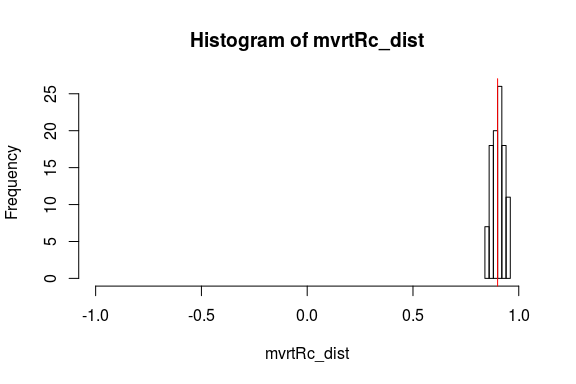

```r
my_hist(mvrtRc_dist)
```

This appears to have worked. Compare with distributions explored in the previous section.

We can also specify a different covariance structure and check again. This demonstrates the usage of the various function definitions we have created for this exercise.

```r
summary(
  get_cor_dist(
    mvrt_R_d,
    100,
    n,
    mu,
    mvrt::convert_R2S(mvrt::make_cor_mat(0.2),var)
    )
  )
```

```
##    Min. 1st Qu.  Median    Mean 3rd Qu.    Max.
##  0.1502  0.1727  0.2059  0.2012  0.2254  0.2500
```

Not surprisingly, the correlation coefficients remain within [0.15,0.25].

## Benchmarking

Let’s see how the functions compare in speed.

```r
microbenchmark::microbenchmark(
  # No data checks
  mvrt_R_a(n, mu, S),               # 'for' loop
  mvrt_R_b(n, mu, S),               # Optimized R code
  mvrt(n, mu, S, n - 1),            # C++ code

  # Iterative checking
  mvrt_R_c(n, mu, S),               # Recursive call
  mvrt_R_d(n, mu, S),               # 'for' loop
  mvrt2(n, mu, S, n - 1, 0.05),     # C++ code

  # Available packages on CRAN
  MASS::mvrnorm(n, mu, S),
  mvtnorm::rmvt(n, S, n - 1) + mu
)
```

```
## Unit: microseconds
##                             expr     min       lq      mean   median
##               mvrt_R_a(n, mu, S)  72.718  78.5400 122.61516  83.8850
##               mvrt_R_b(n, mu, S)  19.886  23.9850  27.10175  25.5405
##            mvrt(n, mu, S, n - 1)   9.381  11.8705  13.20221  13.1005
##               mvrt_R_c(n, mu, S)  47.630  54.0700  71.34679  60.9655
##               mvrt_R_d(n, mu, S)  52.594  59.0750  72.64390  66.7035
##     mvrt2(n, mu, S, n - 1, 0.05)   9.681  14.1485  17.04003  15.5245
##          MASS::mvrnorm(n, mu, S)  51.994  62.3000  67.84426  65.8680
##  mvtnorm::rmvt(n, S, n - 1) + mu 200.643 210.6800 221.45511 215.2740
##        uq      max neval
##   88.6795 3943.055   100
##   28.9940   92.209   100
##   14.2555   19.877   100
##   65.9170  181.545   100
##   75.5140  168.482   100
##   18.1860   40.701   100
##   68.2485  115.516   100
##  222.7995  308.530   100
```

I know the `::` operator has a performance cost for those CRAN packages. It may be interesting to try the benchmarking with loaded packages, too.

```r
MASS_mvrnorm <- MASS::mvrnorm
mvtnorm_rmvt <- mvtnorm::rmvt

microbenchmark::microbenchmark(
  MASS::mvrnorm(n, mu, S),
  MASS_mvrnorm(n, mu, S),
  mvtnorm::rmvt(n, S, n - 1) + mu,
  mvtnorm_rmvt(n, S, n - 1) + mu
)
```

```
## Unit: microseconds
##                             expr     min       lq      mean   median
##          MASS::mvrnorm(n, mu, S)  49.227  55.4755  62.03105  60.1160
##           MASS_mvrnorm(n, mu, S)  42.219  47.9630  52.49261  53.3055
##  mvtnorm::rmvt(n, S, n - 1) + mu 192.175 200.6375 209.81320 208.6435
##   mvtnorm_rmvt(n, S, n - 1) + mu 184.609 191.1385 199.35203 198.2930
##        uq     max neval
##   63.9995 196.735   100
##   57.0505  65.518   100
##  213.2515 349.542   100
##  205.5310 224.457   100
```

## Conclusion

Clearly, rolling your own C++ code is superior. But given the performance gain from removing the `for` loop from our original R function, optimization of R code cannot be underestimated. Given that the well-written R code is comparably performant within an order of magnitude, the switch to C++ is likely not worth the additional effort in this case.